# webMap

```r
#require(tmap)
#require(UScensus2010)
require(choroplethr)
require(choroplethrMaps)
require(choroplethrZip)
require(ggplot2)
require(data.table)
require(bit64)
```

### ZCTA to county info lookup table

#### r package `noncensus`

Seemed to be easy to use, but only mapped one ZCTA to one county. *Not used now*.

```r
# get county name and county code for each row.
library(noncensus)
data(zip_codes)
data(counties)
counties = data.table(counties)
zip_codes = data.table(zip_codes)
counties[, state_fips:= as.character(state_fips)]
counties[, county_fips:= as.character(county_fips)]
zip_codes[, fips := sprintf("%05d", fips)]
# add combined fips for county
counties[, fips := paste0(state_fips, county_fips)]
# merge county info to zipcode rows, now we can match zip to county fips
setkey(counties, fips)
setkey(zip_codes, fips)
zip_counties = merge(zip_codes, counties)
setnames(zip_counties, "zip", "Zip")
setkey(zip_counties, Zip)
```

#### The official [2010 ZCTA relationship file](https://www.census.gov/geo/maps-data/data/zcta_rel_layout.html).

- POPPT ~ Calculated 2010 Population for the relationship record
- ZPOP ~ 2010 Population of the 2010 ZCTA
- ZPOPPCT ~ The Percentage of Total Population of the 2010 ZCTA represented by the record. Some area have 0 or 1 population and 0 or 100 ratio.

There are 33120 unique ZCTAs in 44410 rows, 9036 ZCTAs in them covered more than 1 county, in which 76% have a population distribution higher than 80/20. So we just select the county of most share of population for each ZCTA to work as a simple `temporary workaround`. The better method will be geocoding each specific address to county.

```r
county_fips = fread("data/Geo/2010 FIPS.txt", sep=',', header = TRUE,
                    stringsAsFactors=FALSE,
                    colClasses=list(character=c("StateFP","CountyFP"))) # keep leading 0s
zip_county_fips = fread("data/Geo/zcta_county_rel_10.txt", sep=',', header = TRUE,
                   stringsAsFactors=FALSE,
                   colClasses=list(character=c("ZCTA5","STATE","COUNTY","GEOID")))
# we will call State fips + county fips as countyGEOID in all related data
setnames(zip_county_fips, "GEOID", "countyGEOID")
county_fips[, countyGEOID := paste0(StateFP, CountyFP)]
```

```
##       State StateFP CountyFP        CountyName ClassFP countyGEOID
##    1:    AL      01      001    Autauga County      H1       01001
##    2:    AL      01      003    Baldwin County      H1       01003
##    3:    AL      01      005    Barbour County      H1       01005
##    4:    AL      01      007       Bibb County      H1       01007
##    5:    AL      01      009     Blount County      H1       01009
##   ---
## 3231:    PR      72      153   Yauco Municipio      H1       72153
## 3232:    UM      74      300    Midway Islands      H4       74300
## 3233:    VI      78      010  St. Croix Island      H4       78010
## 3234:    VI      78      020   St. John Island      H4       78020
## 3235:    VI      78      030 St. Thomas Island      H4       78030
```

```r
zip_county = merge(zip_county_fips, county_fips, by = "countyGEOID")
setkey(zip_county, "ZCTA5")
unique(zip_county)[, .N] # 33120 unique zcta in 44410 rows
```

```
## [1] 33120
```

```r
multi_county_zip = zip_county[duplicated(zip_county, by = "ZCTA5") |
             duplicated(zip_county, by = "ZCTA5", fromLast = TRUE) ]
setkey(multi_county_zip, "ZCTA5")
unique(multi_county_zip)[, .N] # 9036 zcta cover more than 1 counties
```

```
## [1] 9036
```

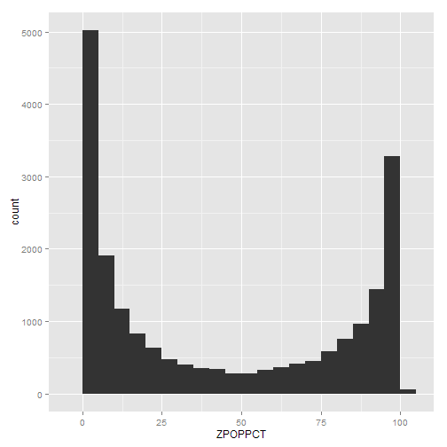

```r
# check the distribution of same ZCTA population among counties
ggplot(multi_county_zip, aes(x=ZPOPPCT)) + geom_histogram(binwidth=5)
```

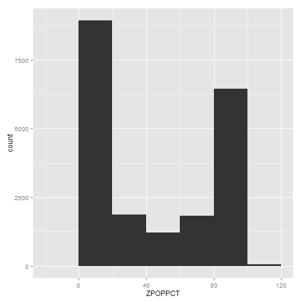

```r
# 76% have more shifted distribution among counties.
ggplot(multi_county_zip, aes(x=ZPOPPCT)) + geom_histogram(binwidth=20)
```

```r
multi_county_zip[ZPOPPCT < 20 | ZPOPPCT > 80, .N] / multi_county_zip[, .N]
```

```
## [1] 0.7588803
```

```r
# only keep the county that have most share of population
selected_county_zip = multi_county_zip[multi_county_zip[, ZPOPPCT == max(ZPOPPCT), by = ZCTA5][, V1]]
# multi_county_zip[multi_county_zip[, .I[which.max(ZPOPPCT)], by = ZCTA5][, V1]] # similar, also works
# Tried which.max directly, but it only find relative index in group. use (http://stackoverflow.com/questions/25320979/finding-the-index-of-the-maximum-value-by-group-for-a-data-table-in-r) instead.
# above method could have selected two counties for same ZCTA if there is a 50/50 split
multi_county_zip[ZPOPPCT == 50] # there are 50 ratios
```

```
##    countyGEOID ZCTA5 STATE COUNTY POPPT HUPT   AREAPT AREALANDPT ZPOP  ZHU
## 1:       42009 16694    42    009   127   63  5114083    5090826  254  118
## 2:       21111 40023    21    111  2059  777 39892219   39289383 4118 1531
##       ZAREA ZAREALAND  COPOP   COHU     COAREA COAREALAND ZPOPPCT ZHUPCT
## 1:  5757029   5733772  49762  23954 2633772365 2621835502      50  53.39
## 2: 59221435  58512979 741096 337616 1029992966  985273984      50  50.75
##    ZAREAPCT ZAREALANDPCT COPOPPCT COHUPCT COAREAPCT COAREALANDPCT State
## 1:    88.83        88.79     0.26    0.26      0.19          0.19    PA
## 2:    67.36        67.15     0.28    0.23      3.87          3.99    KY
##    StateFP CountyFP       CountyName ClassFP
## 1:      42      009   Bedford County      H1
## 2:      21      111 Jefferson County      H1
```

```r
# select zcta by which have 50 ratio, turned out the 50% still is the max share, no need to change results above.
multi_county_zip[multi_county_zip[ZPOPPCT == 50][, ZCTA5]]
```

```
##    countyGEOID ZCTA5 STATE COUNTY POPPT HUPT   AREAPT AREALANDPT ZPOP  ZHU
## 1:       42009 16694    42    009   127   63  5114083    5090826  254  118
## 2:       42057 16694    42    057     8    7    49246      49246  254  118
## 3:       42061 16694    42    061   119   48   593700     593700  254  118
## 4:       21111 40023    21    111  2059  777 39892219   39289383 4118 1531
## 5:       21211 40023    21    211    10    5    27691      26781 4118 1531
## 6:       21215 40023    21    215  2049  749 19301525   19196815 4118 1531
##       ZAREA ZAREALAND  COPOP   COHU     COAREA COAREALAND ZPOPPCT ZHUPCT
## 1:  5757029   5733772  49762  23954 2633772365 2621835502   50.00  53.39
## 2:  5757029   5733772  14845   7122 1134558266 1133252780    3.15   5.93
## 3:  5757029   5733772  45913  22365 2303188808 2265305450   46.85  40.68
## 4: 59221435  58512979 741096 337616 1029992966  985273984   50.00  50.75
## 5: 59221435  58512979  42074  16606  998884967  983253588    0.24   0.33
## 6: 59221435  58512979  17061   6704  496390624  483492140   49.76  48.92
##    ZAREAPCT ZAREALANDPCT COPOPPCT COHUPCT COAREAPCT COAREALANDPCT State
## 1:    88.83        88.79     0.26    0.26      0.19          0.19    PA
## 2:     0.86         0.86     0.05    0.10      0.00          0.00    PA
## 3:    10.31        10.35     0.26    0.21      0.03          0.03    PA
## 4:    67.36        67.15     0.28    0.23      3.87          3.99    KY
## 5:     0.05         0.05     0.02    0.03      0.00          0.00    KY
## 6:    32.59        32.81    12.01   11.17      3.89          3.97    KY
##    StateFP CountyFP        CountyName ClassFP
## 1:      42      009    Bedford County      H1
## 2:      42      057     Fulton County      H1
## 3:      42      061 Huntingdon County      H1
## 4:      21      111  Jefferson County      H1
## 5:      21      211     Shelby County      H1
## 6:      21      215    Spencer County      H1
```

```r
# To get a single ZCTA ~ county mapping table, We just use the "only keep the max portion county" rule in whole dataset, since single county ZCTA will pass the condition too.
zip_county_single = zip_county[zip_county[, ZPOPPCT == max(ZPOPPCT), by = ZCTA5][, V1]]
```

#### [Missouri Census Data Center file](http://mcdc.missouri.edu/cgi-bin/uexplore?/pub/data/corrlst/zip2_xxx)

There are 882 rows of ZCTA “99999” which are not valid ZCTA. They also didn’t include places like Puerto Rico etc.

```r
zip_county_midata = fread("data/Geo/zip2County.csv", sep=',', header = TRUE,
                          stringsAsFactors=FALSE,
                          colClasses=list(character=c("zcta5","county")))
zip_county_midata[zcta5 == "99999",]
```

```
##      zcta5 county      cntyname zipname pop10  afact
##   1: 99999  01003    Baldwin AL   99999     3 0.001
##   2: 99999  01007       Bibb AL   99999     0     0
##   3: 99999  01015    Calhoun AL   99999     5 0.001
##   4: 99999  01021    Chilton AL   99999     0     0
##   5: 99999  01029   Cleburne AL   99999     0     0
##  ---
## 878: 99999  56035   Sublette WY   99999     0     0
## 879: 99999  56037 Sweetwater WY   99999     0     0
## 880: 99999  56041      Uinta WY   99999     0     0
## 881: 99999  56043   Washakie WY   99999     0     0
## 882: 99999  56045     Weston WY   99999     0     0
```

### Data coverage by ZCTA, county, state

- fire incident coverage, chart and map
- NFIRS reporting dept coverage, chart and map
- imputation for non-reporting area
- joint data together, find common high coverage areas.

Turned out each zipcode was visited for 16 times in average. maybe we could use these data locally. Use them globally have too much variation, but use them to compare in local area, may introduce some weight and information.

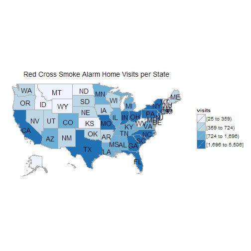

```r
# ----- RC home visits ------------------------------------------------------------------
# coverage_dataname is the list of each item with zip, then extend to county fips
coverage_RC_home = RC_home_visit[, .(.I, Date, Zip)]
setnames(coverage_RC_home, "Zip", "ZCTA5")
# merge county, state information to prepare future aggregation
coverage_RC_home = merge(coverage_RC_home, zip_county_single, by = "ZCTA5")
zip_coverage_RC_home = coverage_RC_home[, .(value = .N), by = ZCTA5]
county_coverage_RC_home = coverage_RC_home[, .(value = .N), by = countyGEOID]
state_coverage_RC_home = coverage_RC_home[, .(value = .N), by = State]
# choropleth for state
data(state.regions)
state_regions = data.table(state.regions)
setnames(state_regions, "abb", "State") # this will be reused for other state choropleths
state_choropleth(merge(state_regions, state_coverage_RC_home, by = "State"),
                 title      = "Red Cross Smoke Alarm Home Visits per State",
                 legend     = "visits",
                 num_colors = 4)
```

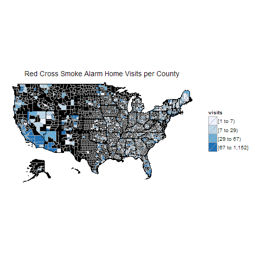

```r
# choropleth for county
data(county.regions)
county_regions = data.table(county.regions)
setnames(county_regions, "county.fips.character", "countyGEOID")
# need to coerce as data frame since data.table will use different merge function
county_choropleth(as.data.frame(merge(county_regions, county_coverage_RC_home,
                                      by = "countyGEOID")),
                 title      = "Red Cross Smoke Alarm Home Visits per County",
                 legend     = "visits",
                 num_colors = 4)
```

```r
# choropleth for ZCTA
data(zip.regions)
zip_regions = data.table(zip.regions)
zip_regions[, ZCTA5 := region]
```

```
##        region state.name   county.name county.fips.numeric  cbsa
##     1:  70560  louisiana        iberia               22045 10020
##     2:  70510  louisiana     vermilion               22113 10020
##     3:  70592  louisiana     lafayette               22055 10020
##     4:  70548  louisiana     vermilion               22113 10020
##     5:  70560  louisiana     vermilion               22113 10020
##    ---
## 51662:  59713    montana        powell               30077    NA
## 51663:  68450   nebraska       johnson               31097    NA
## 51664:  84732       utah         piute               49031    NA
## 51665:  99720     alaska yukon-koyukuk                2290    NA
## 51666:  68324   nebraska          otoe               31131    NA
##        cbsa.title metropolitan.micropolitan.statistical.area ZCTA5
##     1:         NA                                         NA 70560
##     2:         NA                                         NA 70510
##     3:         NA                                         NA 70592
##     4:         NA                                         NA 70548
##     5:         NA                                         NA 70560
##    ---
## 51662:         NA                                         NA 59713
## 51663:         NA                                         NA 68450
## 51664:         NA                                         NA 84732
## 51665:         NA                                         NA 99720
## 51666:         NA                                         NA 68324
```

```r
zip_coverage_RC_home[, region := ZCTA5] # seemed a little bit redundant, but we don't want change the column name in original data into 'region', especially when we want to aggregate on different level from same original data
```

```
##       ZCTA5 value region
##    1: 00602     1  00602
##    2: 00612     8  00612
##    3: 00617     1  00617
##    4: 00627     5  00627
##    5: 00650     1  00650
##   ---
## 3264: 99508    61  99508
## 3265: 99654     7  99654
## 3266: 99676     1  99676
## 3267: 99688     4  99688
## 3268: 99705     5  99705
```

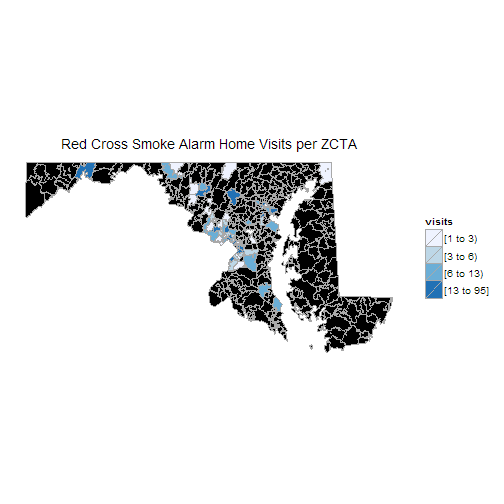

```r
# limit to One state to draw faster and be easier to check.
zip_choropleth(zip_coverage_RC_home,
                 title      = "Red Cross Smoke Alarm Home Visits per ZCTA",
                 state_zoom="maryland",
                 legend     = "visits",
                 num_colors = 4)
```

```r
# ---- RC responses to fire --------------------------------------------------------------
# esri_zip have many missing rows, sort it and saw characters, less than 5 digits, 999s
summary(as.numeric(RC_fire_response$esri_zip)) # 50139 NA include empty and characters.
```

```
##    Min. 1st Qu.  Median    Mean 3rd Qu.    Max.    NA's
##       0   24460   39570   45000   68850  100000   50139
```

```r
summary(as.numeric(RC_fire_response$pre_zip_5_digit)) # 208 NAs, but have many non 5 digits
```

[output not shown]

```r
table(nchar(RC_fire_response$pre_zip_5_digit))
```

```
## < table of extent 0 >
```

```r
# we can ignore all invalid zip by merging with standard ZCTA table
setnames(RC_fire_response, "pre_zip_5_digit", "ZCTA5")
```

[output not shown]

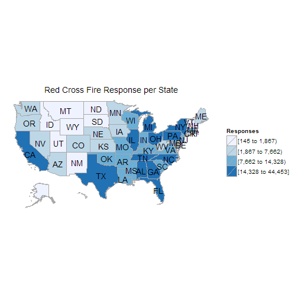

```r
coverage_RC_response = merge(RC_fire_response, zip_county_single, by = "ZCTA5")
zip_coverage_RC_response = coverage_RC_response[, .(value = .N), by = ZCTA5]
county_coverage_RC_response = coverage_RC_response[, .(value = .N), by = countyGEOID]
state_coverage_RC_response = coverage_RC_response[, .(value = .N), by = State]
state_choropleth(merge(state_regions, state_coverage_RC_response, by = "State"),
                 title      = "Red Cross Fire Response per State",
                 legend     = "Responses",
                 num_colors = 4)
```

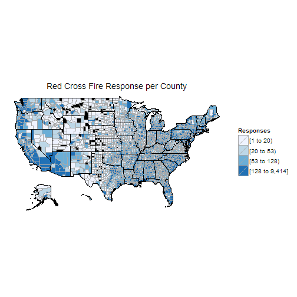

```r
county_choropleth(as.data.frame(merge(county_regions, county_coverage_RC_response, by = "countyGEOID")),
                 title      = "Red Cross Fire Response per County",
                 legend     = "Responses",
                 num_colors = 4)
```

```r
zip_coverage_RC_response[, region := ZCTA5]
```

```
##        ZCTA5 value region
##     1: 00601    10  00601
##     2: 00602     5  00602
##     3: 00603    17  00603
##     4: 00610     9  00610
##     5: 00612    19  00612
##    ---
## 25286: 99919     1  99919
## 25287: 99921     4  99921
## 25288: 99925     2  99925
## 25289: 99926     4  99926
## 25290: 99929     4  99929
```

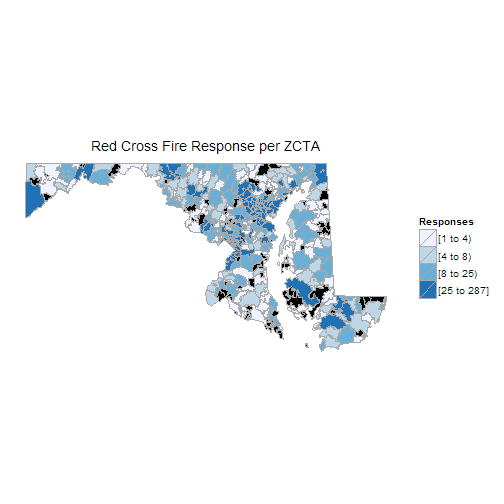

```r
zip_choropleth(zip_coverage_RC_response,
                 title      = "Red Cross Fire Response per ZCTA",
                 state_zoom="maryland",
                 legend     = "Responses",
                 num_colors = 4)
```

```r
# ---- NFIRS data fire incident location coverage -----------------------------------------
# home fire incident
data_all$`2010basicincident`[grep('111', INC_TYPE), .N]
```

```
## [1] 290196
```

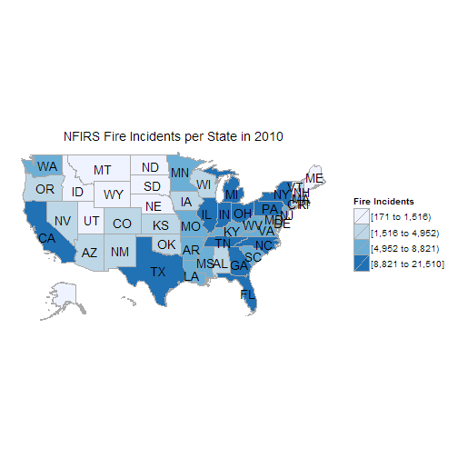

```r
# need address information, merge with home fire events
coverage_NFIRS_home_fire_2010 = merge(data_all$`2010basicincident`[grep('111', INC_TYPE), ],
                                      data_all$`2010incidentaddress`)
# no county info, need to start from zip.
setnames(coverage_NFIRS_home_fire_2010, "ZIP5", "ZCTA5") # is ZIP4 the 4 digits extension zipcode?
# entries with invalid zip will be ignored after merge
matched_coverage_NFIRS_home_fire_2010 = merge(coverage_NFIRS_home_fire_2010, zip_county_single, by = "ZCTA5")
zip_coverage_NFIRS_home_fire_2010 = matched_coverage_NFIRS_home_fire_2010[, .(value = .N), by = ZCTA5]
county_coverage_NFIRS_home_fire_2010 = matched_coverage_NFIRS_home_fire_2010[, .(value = .N), by = countyGEOID]
state_coverage_NFIRS_home_fire_2010 = matched_coverage_NFIRS_home_fire_2010[, .(value = .N), by = State] # if we use the state info in original data before merging with zip list, we could have 8k more entries, but we decided to use same data set to make sure different level maps are consistent
# this is just for coverage. We could use fire/population as fire rate in another map.
state_choropleth(merge(state_regions, state_coverage_NFIRS_home_fire_2010, by = "State"),
                 title      = "NFIRS Fire Incidents per State in 2010",
                 legend     = "Fire Incidents",
                 num_colors = 4)
```

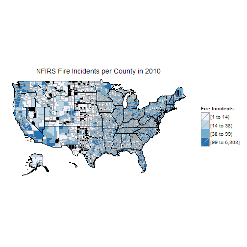

```r
county_choropleth(as.data.frame(merge(county_regions, county_coverage_NFIRS_home_fire_2010, by = "countyGEOID")),
                 title      = "NFIRS Fire Incidents per County in 2010",
                 legend     = "Fire Incidents",
                 num_colors = 4)
```

```r
zip_coverage_NFIRS_home_fire_2010[, region := ZCTA5]
```

```
##        ZCTA5 value region
##     1: 01001    10  01001
##     2: 01002    18  01002
##     3: 01005    12  01005
##     4: 01007     9  01007
##     5: 01008     1  01008
##    ---
## 22622: 99901     6  99901
## 22623: 99919     1  99919
## 22624: 99921     4  99921
## 22625: 99925     4  99925
## 22626: 99929     2  99929
```

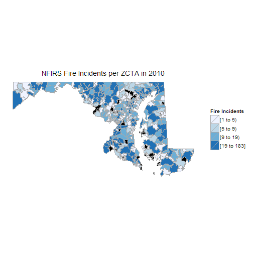

```r
zip_choropleth(zip_coverage_NFIRS_home_fire_2010,
                 title      = "NFIRS Fire Incidents per ZCTA in 2010",
                 state_zoom="maryland",
                 legend     = "Fire Incidents",
                 num_colors = 4)
```

```r
# ----fire departments coverage-----------------------------------------------------------------


# ---- fire incident ratio indicator -----------------------------------------------------------
# smoke alarm presence
# match home fire events id with fireincident data
# 2007, 21377 in 125277 home fire, 2008, 37891 in 134718
home_fire_2010 = merge(data_all$`2010basicincident`[grep('111', INC_TYPE), ],
                                      data_all$`2010fireincident`)


# compare NFIRS reporting fire dept coverage in each year and Fire dept in census
# fdheader in NFIRS have fire dept info, but not complete for zipcode, not necessarily still exist or reporting. the national fire dept data for census have complete info of zipcode but may not include many depts in NFIRS.
# merge full zipcode list with each year occurance and census.


# ---- acs, ahs data ----

# ---- shared high coverage areas, by count and ratio ----
# all areas with above average coverage, count > mean. merge together, rename column first.
```

### state fire incident count, state fire dept coverage map, zipcode map in one state, leaflet zoom in

```r
# county visits on RC home visit: county_coverage_RC_home
```

## Possible methods

- leaflet, self hosted?
- google map with a layer

# —-leaflet—–

1.street level map showing fire incidents from NFIRS and RC response data. * prepare a sample data, estimate the scale of records

2.calculate score on census tract level, or at least zipcode level first(easy and quick, for prototyping), show it as heatmap

3.shiny app to accept user model input.